# 1.7 — Pricing Strategies — Practice Problems

Solutions

ECON 326 — Spring 2023

Promoters of a major college basketball tournament estimate that the demand for tickets for *adults* and by *students* are given by:

$$\begin{aligned}
q_a&=5,000-10p_a\\
q_s&=10,000-100p_s\\
\end{aligned}$$

where $a$ represents adults and $s$ represents students. They estimate that the marginal and average total cost of seating an additional spectator is constant at $10.

## 1. The promoters wish to segment the market and charge adults and students different prices.

### a. For each segment of the market, find the inverse demand function and marginal revenue function.

Take each market segment’s demand function that we are given, and solve for the respective price $p$ to get the two segments’ inverse demand functions. Once we have the inverse demand function, we simply double the slope to find the marginal revenue functions:

#### For adults:

$$\begin{align*}
q_a&=5,000-10p_a\\
q_a+10p_a&=5,000\\
10p_a&=5,000-q_a\\
p_a&=500-0.1q_a\\
\end{align*}$$

With this inverse demand function, we double the slope to obtain marginal revenue:

$$MR(q_a)=500-0.2q_a$$

#### For students:

$$\begin{align*}
q_s&=10,000-100p_s\\
q_s+100p_s&=10,000\\
100p_s&=10,000-q_s\\
p_s&=100-0.01q_s\\
\end{align*}$$

### b. Find the profit-maximizing quantity and price for each segment.

For each segment, set $MR=MC$ to obtain the profit-maximizing quantity of tickets to sell. We know the marginal cost for each segment is simply $10. Then, since the firm has market power, raise the price to the maximum each segment is willing to pay (it’s demand at that quantity).

#### For adults:

$$\begin{align*}
MR(q_a)=MC(q_a)\\
500-0.2q_a&=10\\
500&=10+0.2q_a\\
490&=0.2q_a\\
2,450&=q_a^{\star}\\
\end{align*}$$

Plug this into the adults’ inverse demand curve to obtain the price:

$$\begin{align*}
p_a&=500-0.1q_a\\
p_a&=500-0.1(2,450)\\
p_a&=500-245\\
p_a^{\star}&=\$255\\
\end{align*}$$

#### For students:

$$\begin{align*}
MR(q_s)=MC(q_s)\\
100-0.02q_s&=10\\
100&=10+0.02q_s\\
90&=0.02q_s\\
4,500&=q_s^{\star}\\
\end{align*}$$

Plug this into the students’ inverse demand curve to obtain the price:

$$\begin{align*}
p_s&=100-0.01q_s\\
p_s&=100-0.01(4,500)\\
p_a&=100-45\\
p_a^{\star}&=\$55\\
\end{align*}$$

### c. How much total profit would the tournament earn if they could price discriminate?

Profit is always price minus average cost (which here is the same as marginal cost, always $10) times quantity.

### For adults

$$\begin{align*}
\pi_a&=(p_a-AC(q_a))q_a\\
\pi_a&=(255-10)2,450\\
\pi_a&=\$600,250\\
\end{align*}$$

### For students

$$\begin{align*}
\pi_s&=(p_s-AC(q_s))q_s\\
\pi_s&=(55-10)4,500\\
\pi_s&=\$202,500\\
\end{align*}$$

### Total Profit:

$$\begin{align*}
\Pi&=\pi_a+\pi_s\\
\Pi&=$600,250+\$202,500\\
\Pi&=$600,250+\$202,500\\
\Pi&=802,750\\
\end{align*}$$

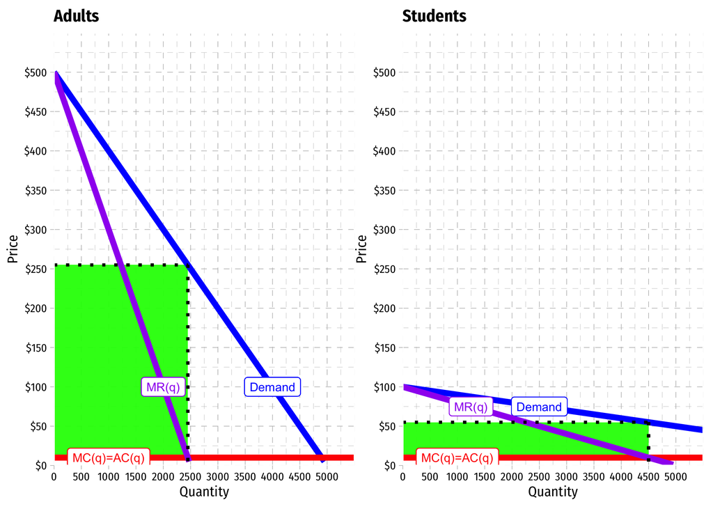

I did not ask this, but we can easily calculate the markup and the price elasticity of demand for each segment, to show you how the optimal pricing rules remain consistent.

### For Adults

$$\begin{align*}
L&=\frac{p-MC(q)}{p}\\
L&=\frac{255-10}{255}\\
L&=0.96\\
\end{align*}$$

About 96% of the price to adults is markup above marginal cost!

The price elasticity of demand for adults at the profit-maximizing price is:

$$\begin{align*}
L&=\frac{1}{\epsilon}\\
0.96&=\frac{1}{\epsilon}\\
\epsilon &= -1.04\\
\end{align*}$$

Adult demand is slightly elastic.

### For Students

$$\begin{align*}
L&=\frac{p-MC(q)}{p}\\
L&=\frac{55-10}{55}\\
L&=0.82\\
\end{align*}$$

About 82% of the price to students is markup above marginal cost.

The price elasticity of demand for students at the profit-maximizing price is:

$$\begin{align*}
L&=\frac{1}{\epsilon}\\
0.82&=\frac{1}{\epsilon}\\
\epsilon &= -1.22\\
\end{align*}$$

Student demand is more elastic.

Hence, we can see because the adults have less elastic demand, the firm will raise the price on them, and they will face a higher markup. Students have more elastic demand, so the firm will lower the price on them (compared to the single price, in question 2, below), and they will face less of a markup.

## 2. Now suppose they could not price discriminate, and were forced to charge the same price for all attendees.

### a. Find the total market demand function.

Simply add the two segments’ demands together to obtain the total market demand:

$$\begin{align*}
Q&=Q_a+q_s\\
Q&=(5,000-10p)+(10,000-100p)\\
Q&=15,000-110p\\
\end{align*}$$

### b. Find the inverse demand function for the total market, and then the marginal revenue function.

Take the market demand and solve for $p$ to find the inverse demand:

$$\begin{align*}
Q&=15,000-110p\\
Q+110p&=15,000\\
110p&=15,000-Q\\
p&=136.36-\frac{1}{110}Q\\
\end{align*}$$

Note if you round (for example, the slope to 0.009), we may get slightly different answers from here on out.

Knowing the inverse demand function, we can double the slope to obtain the marginal revenue function:

$$MR(Q)=136.36-\frac{2}{110}Q$$

### c. Find the profit-maximizing quantity and price for the whole market.

Set $MR(Q)=MC$ to find the profit-maximizing quantity, then plug this into inverse market demand to find the profit-maximizing price.

$$\begin{align*}
MR(Q)=MC(Q)\\
136.36-\frac{2}{110}Q&=10\\
136.36&=10+\frac{2}{110}Q\\
126.36&=\frac{2}{110}Q\\
6,950&\approx Q^{\star}\\
\end{align*}$$
[^1]

Plug this into the market inverse demand curve to obtain the price:

$$\begin{align*}
p&=136.36-\frac{1}{110}Q\\
p&=136.36-\frac{1}{110}(6,950)\\
p&=136.36-63.18\\
p^{\star}&=\$73.18\\
\end{align*}$$

Compare this single price to the price charged to the different segments above. The firm *raised* the price on adults, since they have less elastic demand, and *lowered* the price on students, since they ahve more elastic demand.

### d. How much total profit would the tournament earn if they could not price discriminate?

$$\begin{align*}
\pi&=(p-AC(Q))Q\\
\pi_s&=(73.18-10)6,950\\
\pi_s&=\$439,101\\
\end{align*}$$

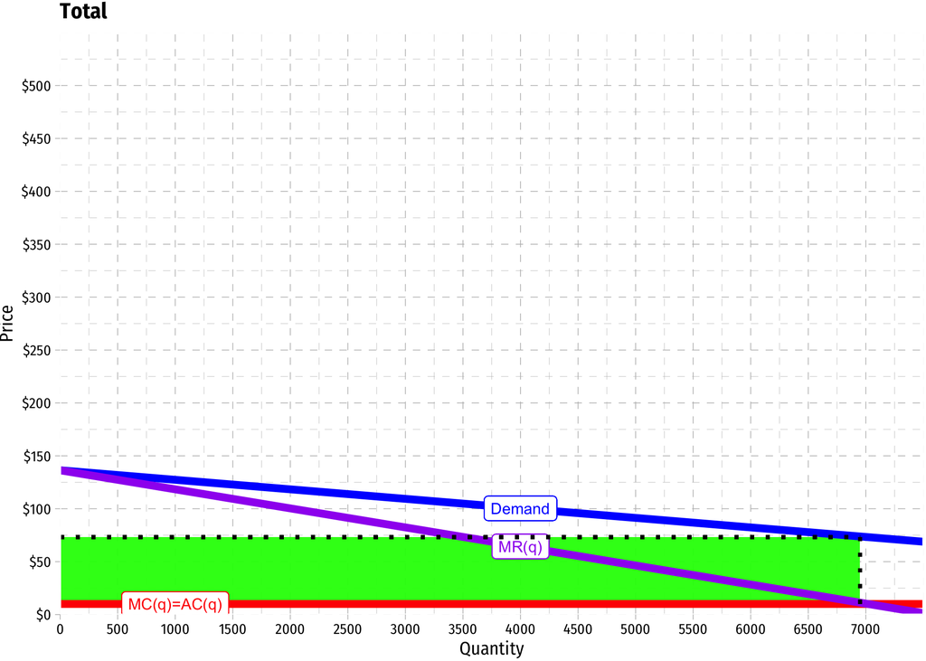

# Technical Appendix

I told you not to worry about this in class, but to be completely accurate, summing the individual segment demands to get the total market demand actually produces a “kinked” market demand curve.

By summing horizontally, add the quantity each segment would purchase at every possible price. Above a price of $100 (the choke price for students), *only* adults will purchase tickets. So above this, it is simply the adults’ demand. At prices below $100, we need to add the quantity of each segment, and this will give us a much more elastic (flatter) total demand curve. Note, the same would be true of the marginal revenue curve (it would be kinked similarly).

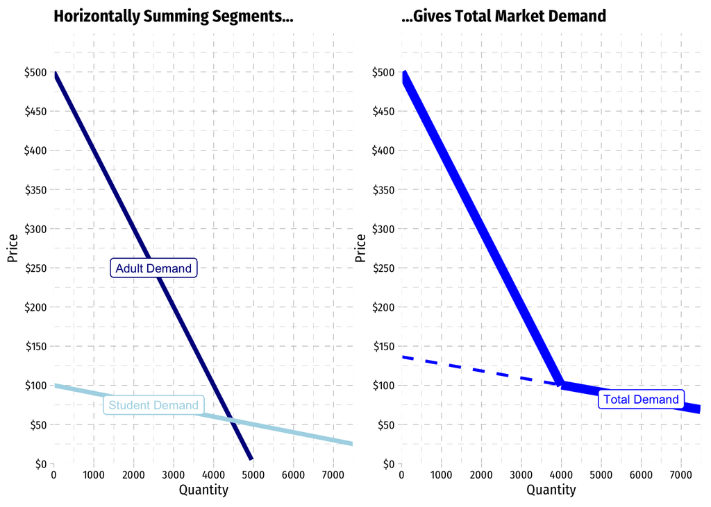

What we did in the problem was to estimate the total demand function as if the entire market demand curve was a straight line (the extrapolated version with the dotted line), as opposed to the true “kinked” demand (solid line).

This will *not* cause a problem (which is why I did not try to explain this in class, since it is a bit more complicated) for what we are doing (finding $Q^{\star}$, $P^{\star}$, and $\pi$ for the total market). However, if we were to try to calculate consumer surplus for the total market (without price discrimination), we would need the true, kinked curve to accurately calculate consumer surplus.

[^1]: Note, to get rid of the $\frac{2}{110}$ in the final step, multiply both sides by $\frac{110}{2}$. Then, I rounded upwards from 6,949.8.